# Exploratory analyses

Regina H. Reynolds

# 1 Background

## 1.1 Aim

- Develop a small brain-relevant marker gene resource for internal use.

# 2 Curating the datasets

## 2.1 Descriptions for metadata columns

| Column | Description |
| --- | --- |
| resource_name | Reference within our database |
| first_author | First author from publication, if published. |
| publication_year | Publication year of resource, if published. |
| publication_link | Link to the publication, if published. |
| species | Species used. |
| tissue_region | Brain region from which tissue was derived. |
| model | If model system used, what was the model? E.g. iPSCs, etc. |
| single_or_bulk | Was single or bulk sequencing applied? |
| number_of_samples | Number of independent biological samples/donors used in sequencing. |
| number_of_cells | Number of cells in single-cell/nuclei analyses. |

[output cut: 4 more lines]

## 2.2 Dataset metadata

| resource_name | first_author | publication_year | publication_link | species | tissue_region | model | single_or_bulk | number_of_samples_donors | number_of_cells | number_of_celltypes_identified_level1 | number_of_celltypes_identified_level2 | download_link | original_filename | data_type |
| --- | --- | --- | --- | --- | --- | --- | --- | --- | --- | --- | --- | --- | --- | --- |
| Agarwal2020_CRTX | Agarwal | 2020 | https://www.ncbi.nlm.nih.gov/geo/query/acc.cgi?acc=GSE140231 | human | cortex | control;post_mortem | single_nuclei | 5 | 12015 | 6 | 23 | https://www.ncbi.nlm.nih.gov/geo/query/acc.cgi?acc=GSE140231 | GSE140231_RAW.tar | SI_matrix |
| Agarwal2020_SNIG | Agarwal | 2020 | https://www.ncbi.nlm.nih.gov/geo/query/acc.cgi?acc=GSE140231 | human | substantia_nigra | control;post_mortem | single_nuclei | 5 | 6105 | 7 | 10 | https://www.ncbi.nlm.nih.gov/geo/query/acc.cgi?acc=GSE140231 | GSE140231_RAW.tar | SI_matrix |
| AIBS2017_MTG | Unpublished | NA | NA | human | middle_temporal_gyrus | control;post_mortem | single_nuclei | 3 | 4401 | 6 | NA | http://celltypes.brain-map.org/rnaseq | ctd_ABI.rda | SI_matrix |
| AIBS2018_MTG | Unpublished | NA | NA | human | middle_temporal_gyrus | control;post_mortem | single_nuclei | 8 | 15928 | 7 | 75 | https://portal.brain-map.org/atlases-and-data/rnaseq/human-mtg-smart-seq | human_MTG_gene_expression_matrices_2018-06-14.zip | SI_matrix |
| Habib2016 | Habib | 2016 | https://science.sciencemag.org/content/353/6302/925.long | mouse | hippocampus | wildtype;brain_homogenate | single_nuclei | NA | 1402 | 11 | 29 | https://github.com/NathanSkene/MAGMA_Celltyping/tree/master/data | ctd_DivSeq.rda | SI_matrix |
| Habib2017_DroNc_Human | Habib | 2017 | https://www.nature.com/articles/nmeth.4407 | human | hippocampus;pre_frontal_cortex | control;post_mortem | single_nuclei | 5 | 19550 | 10 | 15 | https://github.com/NathanSkene/MAGMA_Celltyping/tree/master/data | ctd_DRONC_human.rda | SI_matrix |
| Habib2017_DroNc_Mouse | Habib | 2017 | https://www.nature.com/articles/nmeth.4407 | mouse | hippocampus;pre_frontal_cortex | wildtype;brain_homogenate | single_nuclei | NA | 19561 | 11 | 22 | https://github.com/NathanSkene/MAGMA_Celltyping/tree/master/data | ctd_DRONC_mouse.rda | SI_matrix |
| Lake2018_FrontalCortexOnly | Lake | 2018 | https://www.ncbi.nlm.nih.gov/pubmed/29227469 | human | frontal_cortex_BA6_BA10 | control;post_mortem | single_nuclei | 4 | 10319 | 8 | 24 | https://github.com/NathanSkene/MAGMA_Celltyping | ctd_BlueLake2018_FrontalCortexOnly.Rda | SI_matrix |
| Lake2018_VisualCortexOnly | Lake | 2018 | https://www.ncbi.nlm.nih.gov/pubmed/29227469 | human | visual_cortex_BA17 | control;post_mortem | single_nuclei | 5 | 19368 | 8 | 28 | https://github.com/NathanSkene/MAGMA_Celltyping | ctd_BlueLake2018_VisualCortexOnly.Rda | SI_matrix |
| Skene2018 | Skene | 2018 | https://www.nature.com/articles/s41588-018-0129-5 | mouse | S1_cortex;CA1_hippocampus;hypothalamus;striatum;midbrain | wildtype;brain_homogenate | single_cell | NA | 9970 | 24 | 149 | https://github.com/NathanSkene/MAGMA_Celltyping/tree/master/data | ctd_allKI.rda | SI_matrix |

[output cut: 6 more lines]

- The majority of specificity matrices were downloaded from Skene 2018, but also generated two matrices from:
  - Zeisel et al. 2018 (see: `/home/rreynolds/projects/LDSC_Regression/R/EWCE/Zeisel2018_CNSClusters_FormattingDataForEWCE.R`)
  - Allen Brain Atlas 2019 (see: `../misc_scripts/20190501_AIBS2018_GeneratingSImatrix.R`). Used gene-level (exonic) read count values. While intronic values were available, reckoned that these would tag pre-mRNA.

# 3 Exploring the issue with Zeisel 2015

## 3.1 Distribution of specificity values across studies

- A commonly used marker gene list is from the mouse single cell study, Zeisel 2015. If we were to query this list of these genes across different studies with specificity matrices, how much can we expect specificity values to vary?

```r
# What cell types are there in Zeisel 2015 and how many genes per cell type?
Zeisel2015 %>%
  dplyr::group_by(CellType) %>%
  dplyr::tally()
```

| CellType | n |
| --- | --- |
| Astrocyte | 240 |
| CA1_Pyramidal | 409 |
| Endothelial | 353 |
| Ependymal | 484 |
| Interneuron | 365 |
| Microglia | 436 |
| Mural | 155 |
| Oligodendrocyte | 453 |
| S1_Pyramidal | 294 |

### 3.1.1 Astrocytes

- As an example, chose to look at astrocytes, given that these are known to vary considerably between mouse and human: https://www.ncbi.nlm.nih.gov/pubmed/26687838
- But what are “fair” comparisons?
  - Bear in mind, Zeisel 2015 was:
    - A single cell study
    - Of the somatosensory cortex and CA1 hippocampus
    - In mouse
  - For “fair” comparisons, want to keep as many of the above variables constant.
- Comparisons made:
  - Skene2018: includes cortical as well as hippocampal regions and is a single cell study of the mouse brain.
  - Habib2017_DroNc_Mouse: single nuclear study of PFC and hippocampus, therefore allows some comparison of single cell vs. single nuclear.
  - Habib2017_DroNc_Human: no human specificity matrices are single cell, therefore used Habib as this includes PFC and hippocampus.
  - AIBS2018: human and single nuclear. While this is middle temporal gyrus (i.e. temporal cortex), still cortical and considered the “gold standard”.

```r
# How many genes in Zeisel2015 astrocyte list?
Zeisel2015 %>% filter(CellType == "Astrocyte") %>% .[["Gene"]] %>% unique() %>% length()
```

```
## [1] 240
```

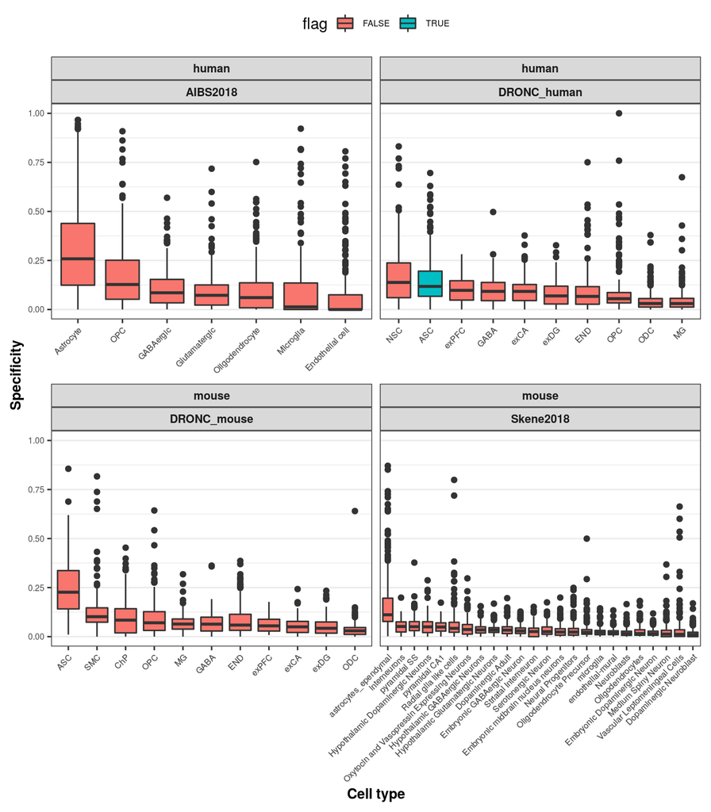

*Figure:* *Displays specificity values of astrocyte marker genes derived from Zeisel 2015 across different cell types within various single-cell/nuclei studies. Within each study, cell types have been ordered by the median specificity.*

```r
# Query across mouse and specificity matrices separately and combine dataframes.
Zeisel_SI <-
  MarkerGenes::query_gene_ctd(genes = Zeisel2015 %>%
                                filter(CellType == "Astrocyte") %>%
                                .[["Gene"]],
                              ctd_allKI, ctd_DRONC_mouse,
                              celltypeLevel = 1,
                              genelistSpecies = "mouse",
                              ctdSpecies = "mouse") %>%
  dplyr::mutate(Species = "mouse") %>%
  bind_rows(MarkerGenes::query_gene_ctd(genes = Zeisel2015 %>%
                                          filter(CellType == "Astrocyte") %>%
                                          .[["Gene"]],
                                        ctd_DRONC_human, ctd_AIBS2018,
                                        celltypeLevel = 1,
                                        genelistSpecies = "mouse",
                                        ctdSpecies = "human") %>%
              dplyr::mutate(Species = "human")) %>%
  dplyr::mutate(Study = str_replace(Study, "ctd_", ""),
                Study = str_replace(Study, "allKI", "Skene2018"))

# Summarise spread of SI across level 1 cell types from each study
MarkerGenes::summarise_specificity_plot(Zeisel_SI %>%
                                          dplyr::mutate(flag = ifelse(CellType == "ASC" & Study == "DRONC_human", T, F)),
                                        fill.variable = "flag")
```

- For the most part, astrocyte marker genes have the highest specificity values within the corresponding astrocyte cell type in each study. The exception, as highlighted by the `flag` variable, is ASC in the human DRONC study.
- The distribution of specificity values for the Zeisel2015 astrocyte marker genes across different astrocytes in each study is variable, with the median varying across each study (see table below), as is the separation of the distribution from other cell types in these studies.

  | Study | CellType | Median |
  | --- | --- | --- |
  | AIBS2018 | Astrocyte | 0.2584526 |
  | DRONC_human | ASC | 0.1177949 |
  | DRONC_mouse | ASC | 0.2264990 |
  | Skene2018 | astrocytes_ependymal | 0.1113185 |

## 3.2 EWCE: Zeisel marker gene lists and level 1 cell types

- Hard to discern how robust these profiles would be, without some testing. Therefore try running EWCE (https://www.frontiersin.org/articles/10.3389/fnins.2016.00016/full) to see whether the marker gene lists have higher expression than would be expected by chance in the relevant cell types.

```r
# Run only once.
# Convert to lists and convert to human genes
list_of_genes <-
  setNames(Zeisel2015 %>%
             group_split(CellType) %>%
             lapply(., function(x) x %>% .[["Gene"]]) %>%
             lapply(., function(x) x %>% convert_between_species(., genelistSpecies = "mouse", ctdSpecies = "human")),
           Zeisel2015 %>%
             .[["CellType"]] %>%
             unique() %>%
             sort())

# Running EWCE only in level 1 cell types
Zeisel_results <-
  MarkerGenes::run_ewce_controlled(list_of_genes, reps = 10000, celltypeLevel = 1,
                                   genelistSpecies = "human", sctSpecies = "mouse",
                                   ctd_allKI, ctd_DRONC_mouse) %>%
  dplyr::mutate(Species = "mouse") %>%
  bind_rows(MarkerGenes::run_ewce_controlled(list_of_genes, reps = 10000, celltypeLevel = 1,
                                             genelistSpecies = "human", sctSpecies = "human",
                                             ctd_DRONC_human, ctd_AIBS2018) %>%
              dplyr::mutate(Species = "human"))

write_csv(Zeisel_results, path = "../results/20190515_EWCE_Zeisel2015_10000bootstrap.csv")
```

- Only ran EWCE using level 1 cell type annotations in each of the studies with provided specificity matrices. Used the same studies used in the prior section investigating distributions of specificity values within the astrocyte marker list from Zeisel 2015.
- Results were multiple test corrected and filtered for those with FDR < 0.05. Given that in several cases, a marker gene list was found significantly enriched in more than one cell type, chosen to summarise results by:
  1. Include a table of with the results for the top 2 cell types wherein the Zeisel 2015 marker list was found signficantly enriched.
  2. Plotting the number of significantly enriched cell types for each of the Zeisel cell type marker lists in each single cell study used.
  3. Plotting the fold difference in the standard deviations from the mean between the top 2 enriched cell types. Standard deviations from the mean is a measure of the distance between expression in the target list from the mean level of expression the bootstrapped sample.

| MarkerList | Study | CellType | sd_from_mean | FDR |
| --- | --- | --- | --- | --- |
| Astrocyte | AIBS2019 | Astrocyte | 16.0738707946475 | 0 |
| Astrocyte | AIBS2019 | OPC | 5.13527237568249 | 0 |
| CA1_Pyramidal | AIBS2019 | Glutamatergic | 8.75402817984005 | 0 |
| CA1_Pyramidal | AIBS2019 | GABAergic | 7.65623369582151 | 0 |
| Endothelial | AIBS2019 | Endothelial cell | 19.61026870888 | 0 |
| Ependymal | AIBS2019 | Astrocyte | 8.77320555277395 | 0 |
| Ependymal | AIBS2019 | Glutamatergic | 5.53224023563105 | 0 |
| Interneuron | AIBS2019 | GABAergic | 22.2623404658878 | 0 |
| Interneuron | AIBS2019 | OPC | 2.39588905751188 | 0.043992 |
| Microglia | AIBS2019 | Microglia | 36.6377845090947 | 0 |

[output cut: 53 more lines]

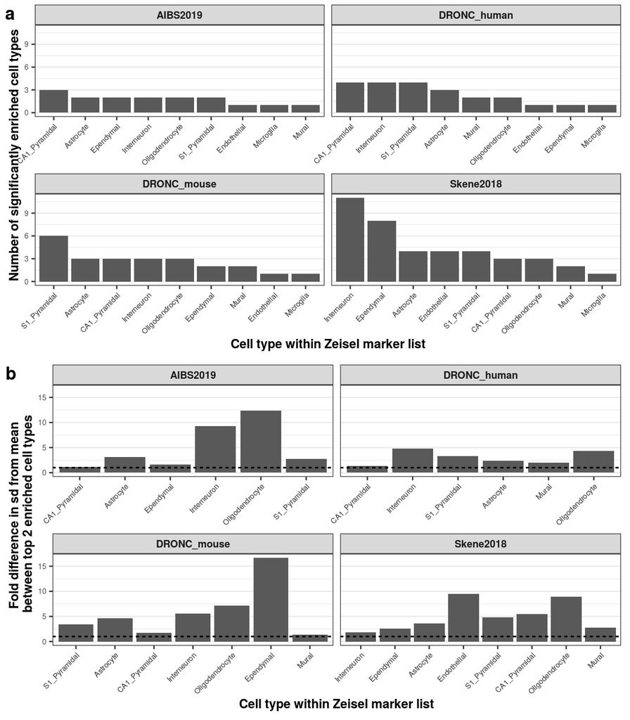

*Figure:* *a) Plot displaying the number of significantly enriched cell types found using each of the Zeisel marker lists. b) Plot for those Zeisel marker gene lists with more than one significant enriched cell type displaying fold difference between the standard deviations from the mean of the top enriched cell type (as ranked by the standard deviations from the mean) divided by the standard deviations from the mean of the second enriched cell type. Dashed line indicates a fold difference of 1. In both a and b, marker lists are orderd within each study by the number of significantly enriched cell types.*

# 4 Exploring the issue with Wang 2018

- In the recent flagship publication from the larger PsychENCODE release (https://science.sciencemag.org/content/362/6420/eaat8464), the authors curated two flat gene lists to be used as markers for cell types.
- The difference between these two lists was whether they were generated from single nuclear studies using either UMI or TPM. They were curated using:
  - TPM: Marker genes merged from Darmanis 2015 and Lake 2016 sources.
  - UMI: Marker genes merged from PsychENCODE and Lake 2018.
- In the original paper, a comparison of gene expression profiles based on marker genes of TPM and UMI datasets showed that these were very similar. Would expect this to be reflected in EWCE results.

| combined | n |
| --- | --- |
| TPM:Adult-Astro | 40 |
| TPM:Adult-Endo | 83 |
| TPM:Adult-Ex1 | 18 |
| TPM:Adult-Ex2 | 11 |
| TPM:Adult-Ex3 | 9 |
| TPM:Adult-Ex4 | 17 |
| TPM:Adult-Ex5 | 21 |
| TPM:Adult-Ex6 | 38 |
| TPM:Adult-Ex7 | 6 |
| TPM:Adult-Ex8 | 65 |

[output cut: 39 more lines]

- Note: in general, there are many more marker genes in the UMI-defined cell types as compared to the TPM-defined cell types.

## 4.1 Distribution of specificity values

### 4.1.1 Astrocytes

#### 4.1.1.1 TPM

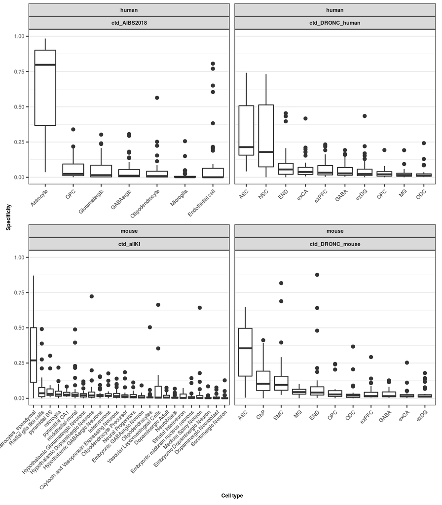

*Figure:* *Displays specificity values of astrocyte marker genes derived from Wang 2018 TPM across different cell types within various single-cell/nuclei studies. Within each study, cell types have been ordered by the median specificity.*

#### 4.1.1.2 UMI

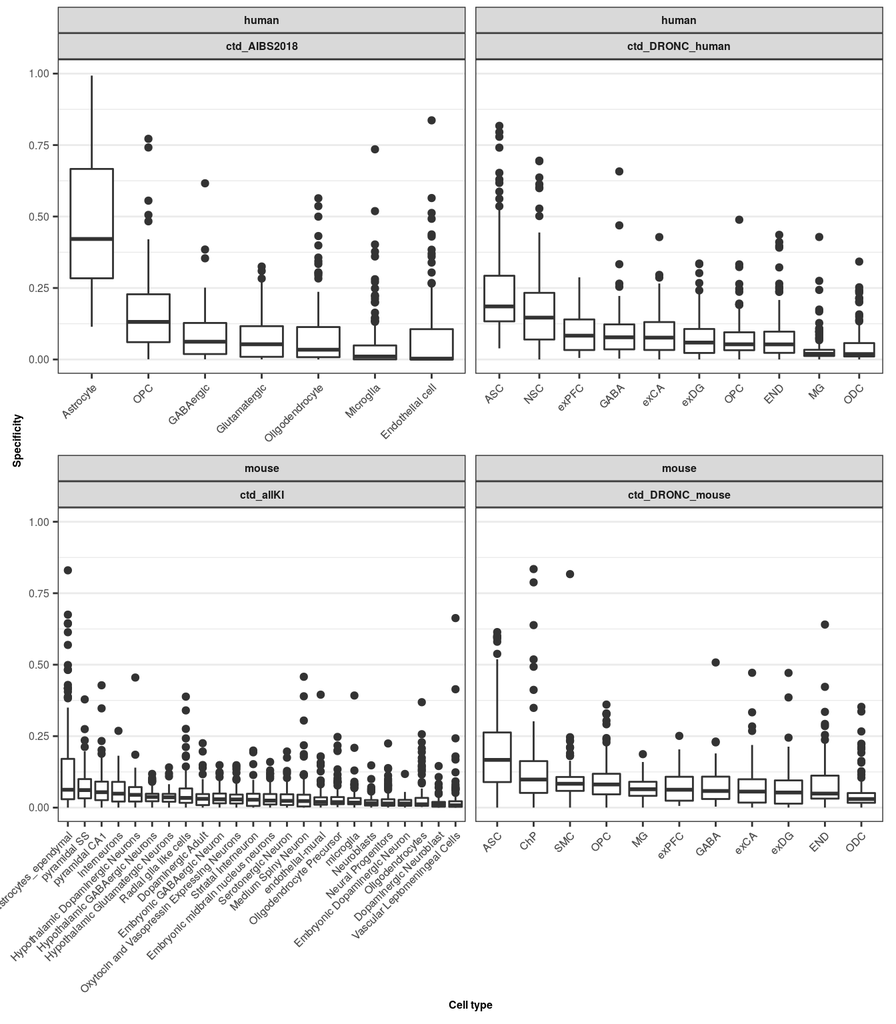

*Figure:* *Displays specificity values of astrocyte marker genes derived from Wang 2018 UMI across different cell types within various single-cell/nuclei studies. Within each study, cell types have been ordered by the median specificity.*

#### 4.1.1.3 Medians

| Technology | Study | CellType | Median |
| --- | --- | --- | --- |
| TPM | ctd_AIBS2018 | Astrocyte | 0.79793180 |
| TPM | ctd_allKI | astrocytes_ependymal | 0.26871975 |
| TPM | ctd_DRONC_human | ASC | 0.21391047 |
| TPM | ctd_DRONC_mouse | ASC | 0.35485513 |
| UMI | ctd_AIBS2018 | Astrocyte | 0.42145900 |
| UMI | ctd_allKI | astrocytes_ependymal | 0.06245905 |
| UMI | ctd_DRONC_human | ASC | 0.18552222 |
| UMI | ctd_DRONC_mouse | ASC | 0.16699370 |

- TPM-derived astrocyte markers had a much higher median across all studies compared to both UMI-derived astrocyte markers and Zeisel 2015 astrocyte markers. UMI-derived astrocyte markers had a higher median than Zeisel astrocyte markers in both human studies, but a lower median than Zeisel astrocyte markers in mouse studies.

## 4.2 EWCE: Wang marker gene lists and level 1 cell types

- Only ran EWCE using level 1 cell type annotations in each of the studies with provided specificity matrices. Used only human studies from prior section investigating distributions of specificity values.
- Results were multiple test corrected and filtered for those with FDR < 0.05.

```r
# Run only once.
# OBS. EWCE only works if more than four genes provided. Any lists smaller than 4?
Wang2018 %>%
  dplyr::group_by(combined) %>%
  dplyr::tally() %>%
  dplyr::filter(n < 4)

# Remove lists with fewer genes than required
list_of_genes <- setNames(Wang2018 %>%
                            dplyr::filter(!combined == "TPM:Adult-In1") %>%
                            group_split(combined) %>%
                            lapply(., function(x) x %>% .[["Gene"]]),
                          Wang2018 %>%
                            dplyr::filter(!combined == "TPM:Adult-In1") %>%
                            .[["combined"]] %>%
                            unique() %>%
                            sort())


# Running EWCE only in level 1 cell types and in human studies
Wang_results_human <-
  MarkerGenes::run_ewce_controlled(list_of_genes, reps = 10000, celltypeLevel = 1,
                                   genelistSpecies = "human", sctSpecies = "human",
                                   ctd_DRONC_human, ctd_AIBS2018) %>%
  dplyr::mutate(Species = "human")

write_csv(Wang_results_human, path = "../results/20190523_EWCE_Wang2018_human_10000bootstrap.csv")
```

### 4.2.1 TPM

| MarkerList | Study | CellType | sd_from_mean | FDR |
| --- | --- | --- | --- | --- |
| TPM:Adult-Astro | AIBS2019 | Astrocyte | 20.7849492491145 | 0 |
| TPM:Adult-Endo | AIBS2019 | Oligodendrocyte | 12.684858827144 | 0 |
| TPM:Adult-Endo | AIBS2019 | Endothelial cell | 8.58956933858471 | 0 |
| TPM:Adult-Ex1 | AIBS2019 | GABAergic | 4.73755588757369 | 0.00103291139240506 |
| TPM:Adult-Ex1 | AIBS2019 | Glutamatergic | 3.0223510010465 | 0.0202897297297297 |
| TPM:Adult-Ex4 | AIBS2019 | Glutamatergic | 6.83000324226004 | 0 |
| TPM:Adult-Ex5 | AIBS2019 | Glutamatergic | 4.71991091277592 | 0 |
| TPM:Adult-Ex6 | AIBS2019 | Astrocyte | 2.72804540867497 | 0.032725 |
| TPM:Adult-Ex6 | AIBS2019 | OPC | 2.62704503335829 | 0.0393353846153846 |
| TPM:Adult-Ex7 | AIBS2019 | OPC | 4.27830869975896 | 0.00336 |

[output cut: 38 more lines]

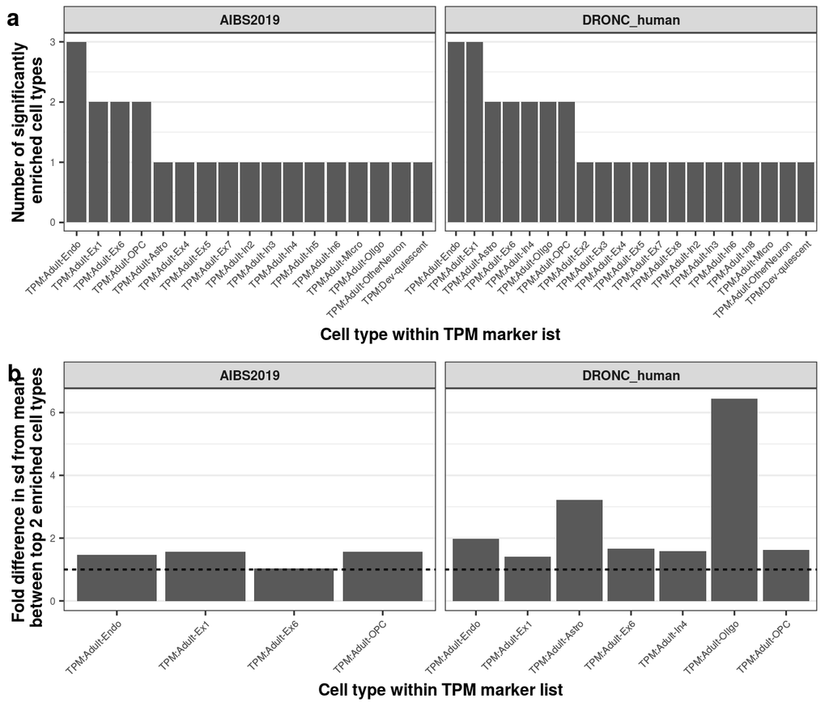

*Figure:* *a) Plot displaying the number of significantly enriched cell types found using each of the Wang 2018 TPM marker lists. b) Plot for those TPM marker gene lists with more than one significant enriched cell type displaying fold difference between the standard deviations from the mean of the top enriched cell type (as ranked by the standard deviations from the mean) divided by the standard deviations from the mean of the second enriched cell type. Dashed line indicates a fold difference of 1. In both a and b, marker lists are orderd within each study by the number of significantly enriched cell types.*

#### 4.2.1.1 Summary of TPM results

- Firstly, worth noting that some of the marker lists do not identify a significantly enriched cell type in the study, and therefore are not displayed on the plot. This includes:

| GeneSet | Study | n |
| --- | --- | --- |
| TPM:Adult-Ex2 | AIBS2019 | 11 |
| TPM:Adult-Ex3 | AIBS2019 | 9 |
| TPM:Adult-Ex8 | AIBS2019 | 65 |
| TPM:Adult-In5 | DRONC | 11 |
| TPM:Adult-In7 | DRONC | 13 |
| TPM:Adult-In7 | AIBS2019 | 13 |
| TPM:Adult-In8 | AIBS2019 | 4 |
| TPM:Dev-replicating | DRONC | 40 |
| TPM:Dev-replicating | AIBS2019 | 40 |

- This is in large part due to the small sizes of theses lists, in addition to the expression filtering that the EWCE package applies when it creates specificity matrices for use in enrichment analyses.
- TPM marker lists had a number of significant enrichments in cell types that did not fit with the identity of the marker lists, including:
  - Endothelial markers enriched in oligodendrocytes. They also enriched within endothelial cells, however, this was the second enriched cell type when ranked by sd from the mean.
  - Ex6, Ex7 and Ex8 were enriched with OPCs.
  - Dev-quiescent in OPCs, although this perhaps makes sense in that these are the only “progenitor”-like cells in the single-cell studies, thus their transcriptional profiles may match up better with a quiescent developmental cell type.

### 4.2.2 UMI

| MarkerList | Study | CellType | sd_from_mean | FDR |
| --- | --- | --- | --- | --- |
| UMI:Astro | AIBS2019 | Astrocyte | 28.2093372220144 | 0 |
| UMI:Astro | AIBS2019 | OPC | 2.30474451386496 | 0.0496871287128713 |
| UMI:Endo | AIBS2019 | Endothelial cell | 24.4058722834826 | 0 |
| UMI:Ex1 | AIBS2019 | Glutamatergic | 25.6423908656102 | 0 |
| UMI:Ex1 | AIBS2019 | GABAergic | 7.38252049022316 | 0 |
| UMI:Ex2 | AIBS2019 | Glutamatergic | 20.3526119887444 | 0 |
| UMI:Ex2 | AIBS2019 | GABAergic | 5.26924620614029 | 0 |
| UMI:Ex3e | AIBS2019 | Glutamatergic | 17.7118982961212 | 0 |
| UMI:Ex3e | AIBS2019 | GABAergic | 9.31941662874916 | 0 |
| UMI:Ex4 | AIBS2019 | Glutamatergic | 22.1443835908382 | 0 |

[output cut: 83 more lines]

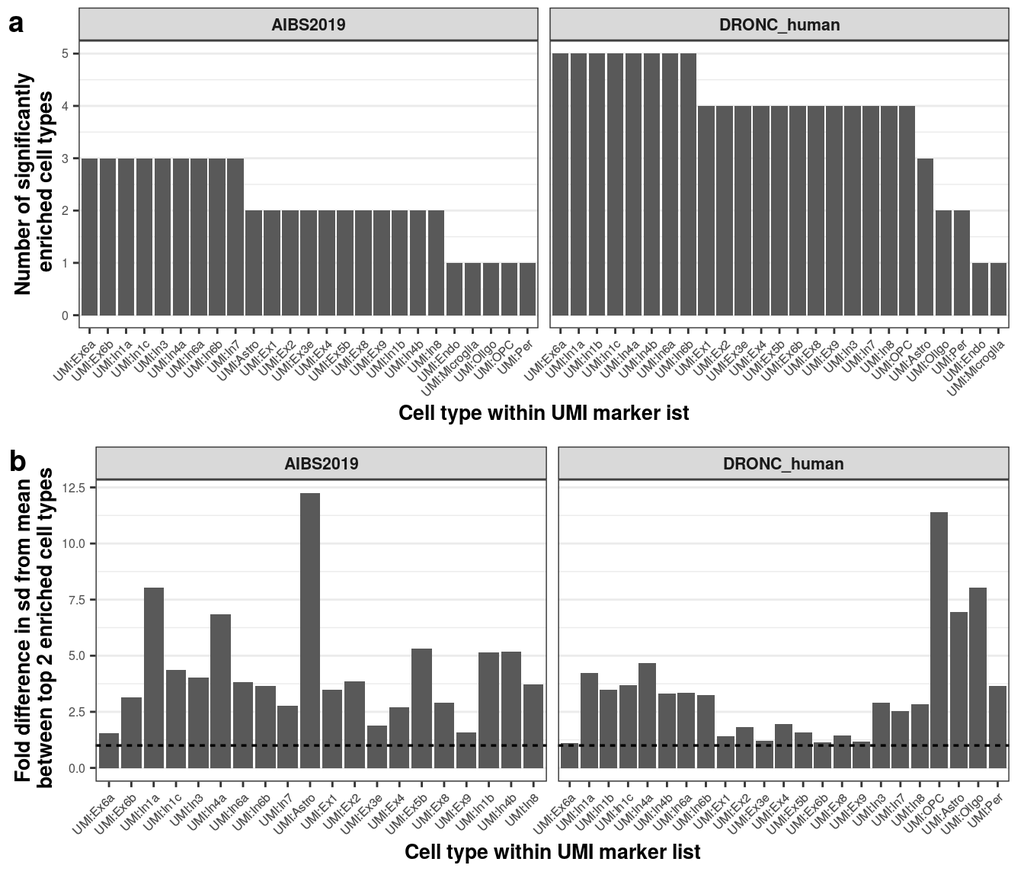

*Figure:* *a) Plot displaying the number of significantly enriched cell types found using each of the Wang 2018 UMI marker lists. b) Plot for those UMI marker gene lists with more than one significant enriched cell type displaying fold difference between the standard deviations from the mean of the top enriched cell type (as ranked by the standard deviations from the mean) divided by the standard deviations from the mean of the second enriched cell type. Dashed line indicates a fold difference of 1. In both a and b, marker lists are orderd within each study by the number of significantly enriched cell types.*

#### 4.2.2.1 Summary of UMI results

- The majority of UMI markers are significantly enriched in more than one cell type, but typically show a preference for one cell type over the other. E.g. The Ex and In sub-categories are found signficantly enriched within both the glutamatergic and GABAergic classes from the AIBS2018 study, but preferentially enrich in the class you would expect (i.e. Ex in glutamatergic and In in GABAergic).

## 4.3 EWCE: UMI Wang marker lists and AIBS2018 level 2 cell types

- Decided to focus only on UMI markers, given that they might contain a sufficient number of genes to provide some robust distinction.
- Furthermore, focussed on the AIBS2018 study as there are 75 different level 2 cell types, as opposed to only 15 in the DRONC study, so there is a real opportunity to put the lists to the test in distinguishing between level 2 cell types.

```r
# Run only once.
# Remove lists with fewer genes than required
list_of_genes <- setNames(Wang2018 %>%
                            dplyr::filter(str_detect(combined, "UMI")) %>%
                            group_split(combined) %>%
                            lapply(., function(x) x %>% .[["Gene"]]),
                          Wang2018 %>%
                            dplyr::filter(str_detect(combined, "UMI")) %>%
                            .[["combined"]] %>%
                            unique() %>%
                            sort())


# Running EWCE only in level 2 cell types and in AIBS2018
Wang_results_UMI <- run_ewce_controlled(list_of_genes, reps = 10000, celltypeLevel = 2,
                               genelistSpecies = "human", sctSpecies = "human",
                               ctd_AIBS2018)
write_csv(Wang_results_UMI, path = "../results/20190523_EWCE_Wang2018_UMI_AIBS2018_10000bootstrap.csv")
```

```r
# Apply multiple test correction
Wang_results_UMI <- read_csv(file = "../results/20190523_EWCE_Wang2018_UMI_AIBS2018_10000bootstrap.csv") %>%
  dplyr::mutate(FDR = p.adjust(p, method = "BH"))
```

### 4.3.1 Summary of results

- The issue at this level of cell types is the number of significant enrichments found (438) across the 25 UMI marker lists.
- Looking at the top 2 enriched cell types for each list, they appear to match the cell type implied by the marker list.

| GeneSet | CellType | sd_from_mean | FDR |
| --- | --- | --- | --- |
| UMI:Astro | Astro_L1-6_FGFR3_SLC14A1 | 33.8122621053525 | 0 |
| UMI:Astro | Astro_L1-2_FGFR3_GFAP | 21.7307033447376 | 0 |
| UMI:Ex1 | Exc_L2-3_LINC00507_FREM3 | 21.5969459126288 | 0 |
| UMI:Ex1 | Exc_L2_LAMP5_LTK | 20.3773110398003 | 0 |
| UMI:Ex2 | Exc_L2-3_LINC00507_FREM3 | 14.4131481362534 | 0 |
| UMI:Ex2 | Exc_L5-6_THEMIS_C1QL3 | 14.0418722533792 | 0 |
| UMI:Ex3e | Exc_L4-6_RORB_SEMA3E | 15.3970578121288 | 0 |
| UMI:Ex3e | Exc_L5-6_THEMIS_C1QL3 | 11.8273311941838 | 0 |
| UMI:Ex4 | Exc_L3-5_RORB_ESR1 | 19.5052436480114 | 0 |
| UMI:Ex4 | Exc_L4-6_RORB_SEMA3E | 16.757990874867 | 0 |

[output cut: 36 more lines]

- Notably, the number of cell types within which the marker lists are enriched is quite high for most marker lists (especially neuronal marker lists), and the fold difference in sd from the mean (which was used to rank cell types in previous plots) between the first and second enriched cell type is not large (see below). For those marker lists with many significantly enriched cell types, the fold difference between the top 2 cell types is often < 2, implying that the ability to distinguish between the two based on the provided marker list is minimal.

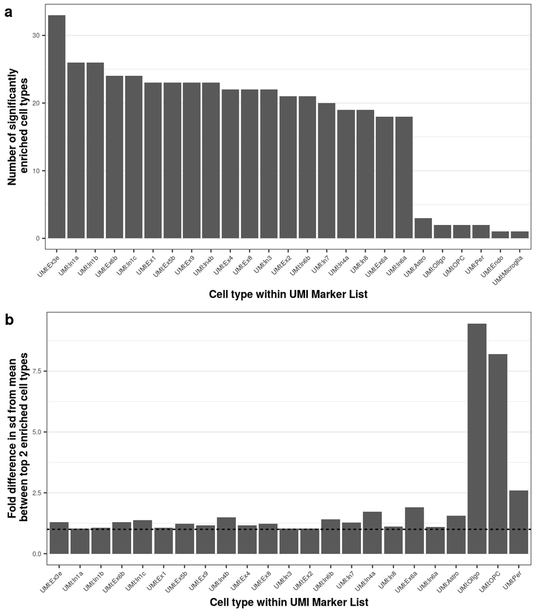

*Figure:* *a) Plot displaying the number of significantly enriched cell types found using each of the UMI marker lists. b) Plot displaying the fold difference between the standard deviations from the mean of the top enriched cell type (as ranked by the standard deviations from the mean) divided by the standard deviations from the mean of the second enriched cell type. Dashed line indicates a fold difference of 1.*

# 5 Brief conclusions

- Both the Zeisel 2015 and the UMI markers from Wang 2018 are robust across level 1 cell types. In other words, they can identify and distinguish between the broader classes of cell type.
- Species-matched lists appear to perform better as based on the followed observations:
  1. For those Zeisel marker lists found to be enriched in more than one cell type, the fold difference between sd from the mean for the top two cell types was higher in mouse single-cell studies, as compared to human studies.
  2. A comparison of the median fold difference of the mouse-derived Zeisel and human-derived UMI marker in the AIBS2018 study (using only level 1 cell types) found the median fold difference to be higher when using the species-matched list (UMI, median = 3.77; Zeisel, median = 2.92).
- In terms of distinguishing level 2 cell types, the UMI marker list did not prove particularly well suited. Each individual UMI marker list was often found enriched in a number of related level 2 cell types, with little to distinguish between the enrichments.

# 6 Open questions

- How would marker lists perform across disease states or varying age groups?
- How do these lists perform using other methods e.g. MetaNeighbor (https://www.nature.com/articles/s41467-018-03282-0)?